# df

Autogenerated data summary from dataMaid

2023-10-05 21:01:18.776426

# Data report overview

The dataset examined has the following dimensions:

| Feature | Result |
| --- | --- |
| Number of observations | 162 |
| Number of variables | 42 |

### Checks performed

The following variable checks were performed, depending on the data type of each variable:

|  | character | factor | labelled | haven labelled | numeric | integer | logical | Date |
| --- | --- | --- | --- | --- | --- | --- | --- | --- |
| Identify miscoded missing values | × | × | × | × | × | × |  | × |
| Identify prefixed and suffixed whitespace | × | × | × | × |  |  |  |  |
| Identify levels with < 6 obs. | × | × | × | × |  |  |  |  |
| Identify case issues | × | × | × | × |  |  |  |  |
| Identify misclassified numeric or integer variables | × | × | × | × |  |  |  |  |
| Identify outliers |  |  |  |  | × | × |  | × |

Please note that all numerical values in the following have been rounded to 2 decimals.

# Summary table

|  | Variable class | # unique values | Missing observations | Any problems? |
| --- | --- | --- | --- | --- |
| X | integer | 162 | 0.00 % |  |
| renewvia_id | integer | 149 | 0.00 % |  |
| avg_household_income_pre | numeric | 46 | 0.62 % |  |
| appliances_count_pre | numeric | 9 | 5.56 % | × |
| cellphones_count_pre | numeric | 10 | 3.70 % | × |
| light_hours_current_pre | numeric | 10 | 4.32 % |  |
| kerosene_lamps_count_pre | numeric | 8 | 0.00 % | × |
| business_owners_count_pre | integer | 3 | 0.00 % | × |
| business_owners_female_pre | integer | 2 | 0.00 % |  |
| community_lights_pre | numeric | 2 | 0.00 % |  |
| home_exterior_lights_pre | numeric | 3 | 1.23 % |  |
| clinic_refrigeration_access_pre | numeric | 3 | 4.32 % |  |
| cooking_fuel_collection_time_pre | numeric | 4 | 0.00 % | × |
| cooking_energy_cost_pre | numeric | 5 | 5.56 % | × |
| feel_safe_dark_pre | numeric | 5 | 0.00 % | × |
| feel_safe_if_exterior_lights_pre | numeric | 5 | 0.00 % | × |
| water_source_pre | numeric | 5 | 0.62 % | × |
| water_collection_travel_distance_pre | numeric | 5 | 10.49 % | × |
| water_collection_time_pre | numeric | 6 | 1.85 % | × |
| water_cost_pre | numeric | 4 | 1.85 % |  |
| clinic_travel_distance_pre | numeric | 4 | 59.26 % | × |
| phone_charge_cost_pre | numeric | 5 | 15.43 % | × |
| avg_household_income_post | numeric | 45 | 0.00 % | × |
| appliances_count_post | numeric | 6 | 0.00 % | × |
| cellphones_count_post | numeric | 7 | 7.41 % | × |
| light_hours_current_post | numeric | 12 | 2.47 % | × |
| kerosene_lamps_count_post | numeric | 6 | 0.00 % | × |
| business_owners_count_post | integer | 2 | 0.00 % |  |
| business_owners_female_post | integer | 2 | 0.00 % |  |
| community_lights_post | numeric | 2 | 0.00 % |  |
| home_exterior_lights_post | numeric | 3 | 1.23 % |  |
| clinic_refrigeration_access_post | numeric | 3 | 7.41 % |  |
| cooking_fuel_collection_time_post | numeric | 4 | 0.00 % | × |
| cooking_energy_cost_post | numeric | 3 | 0.00 % |  |
| feel_safe_dark_post | numeric | 5 | 0.00 % | × |
| feel_safe_if_exterior_lights_post | numeric | 5 | 0.00 % | × |
| water_source_post | numeric | 4 | 2.47 % | × |
| water_collection_travel_distance_post | numeric | 4 | 0.00 % | × |
| water_collection_time_post | numeric | 5 | 0.00 % | × |
| water_cost_post | numeric | 3 | 0.00 % | × |
| clinic_travel_distance_post | numeric | 5 | 61.11 % | × |
| phone_charge_cost_post | logical | 1 | 100.00 % | × |

# Variable list

## X

| Feature | Result |
| --- | --- |
| Variable type | integer |
| Number of missing obs. | 0 (0 %) |
| Number of unique values | 162 |
| Median | 80.5 |
| 1st and 3rd quartiles | 40.25; 120.75 |
| Min. and max. | 0; 161 |

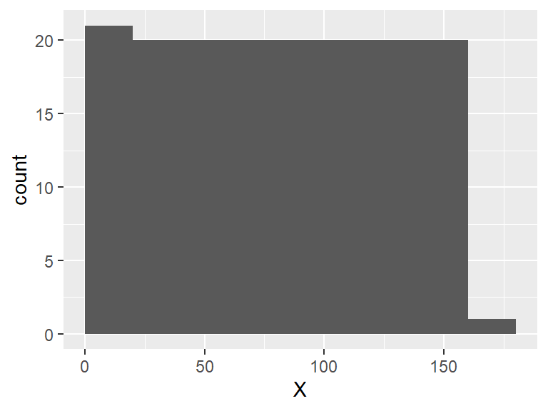

## renewvia_id

| Feature | Result |
| --- | --- |
| Variable type | integer |
| Number of missing obs. | 0 (0 %) |
| Number of unique values | 149 |
| Median | 224652.5 |
| 1st and 3rd quartiles | 190168.25; 242248.75 |
| Min. and max. | 131268; 252219 |

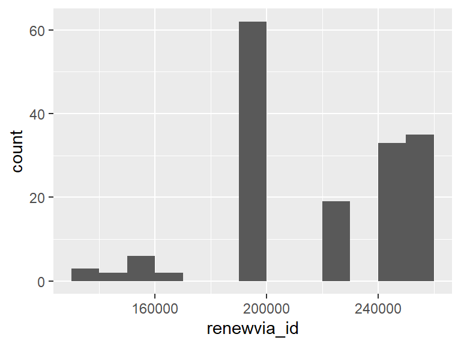

## avg_household_income_pre

| Feature | Result |
| --- | --- |
| Variable type | numeric |
| Number of missing obs. | 1 (0.62 %) |
| Number of unique values | 45 |
| Median | 500 |
| 1st and 3rd quartiles | 55; 3500 |
| Min. and max. | 0; 30000 |

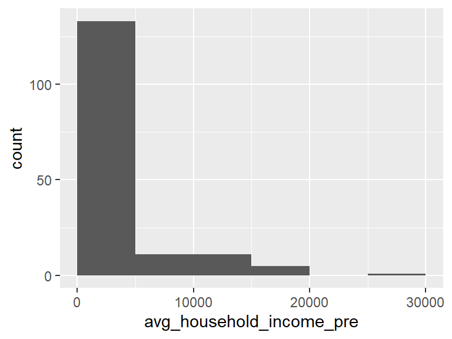

## appliances_count_pre

| Feature | Result |
| --- | --- |
| Variable type | numeric |
| Number of missing obs. | 9 (5.56 %) |
| Number of unique values | 8 |
| Median | 2 |
| 1st and 3rd quartiles | 2; 3 |
| Min. and max. | 0; 24 |

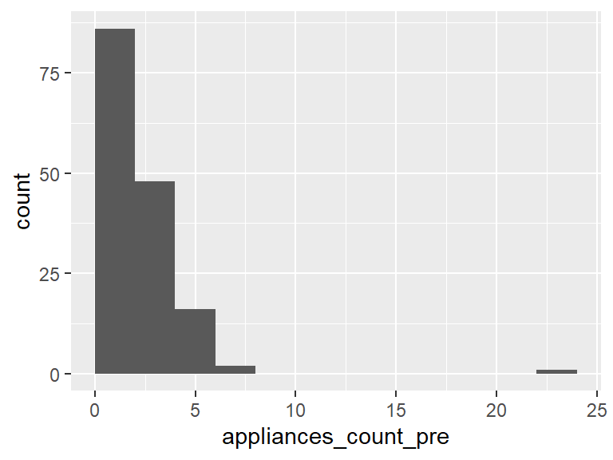

## cellphones_count_pre

| Feature | Result |
| --- | --- |
| Variable type | numeric |
| Number of missing obs. | 6 (3.7 %) |
| Number of unique values | 9 |
| Median | 2 |
| 1st and 3rd quartiles | 2; 4 |
| Min. and max. | 1; 9 |

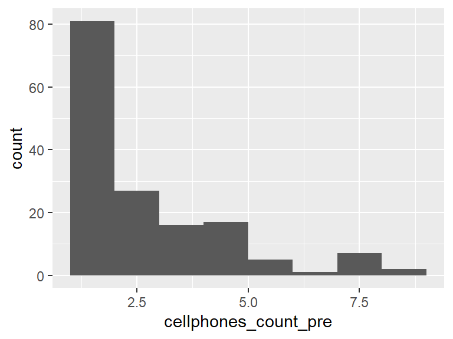

## light_hours_current_pre

| Feature | Result |
| --- | --- |
| Variable type | numeric |
| Number of missing obs. | 7 (4.32 %) |
| Number of unique values | 9 |
| Median | 3 |
| 1st and 3rd quartiles | 2; 5 |
| Min. and max. | 1; 12 |

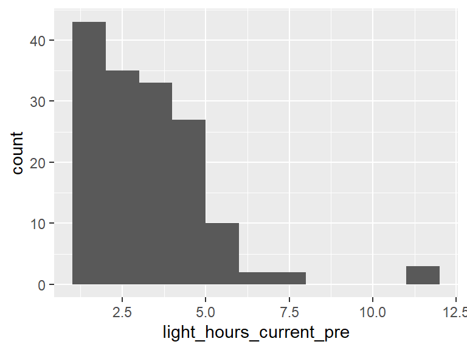

## kerosene_lamps_count_pre

| Feature | Result |
| --- | --- |
| Variable type | numeric |
| Number of missing obs. | 0 (0 %) |
| Number of unique values | 8 |
| Median | 1 |
| 1st and 3rd quartiles | 0; 2 |
| Min. and max. | 0; 8 |

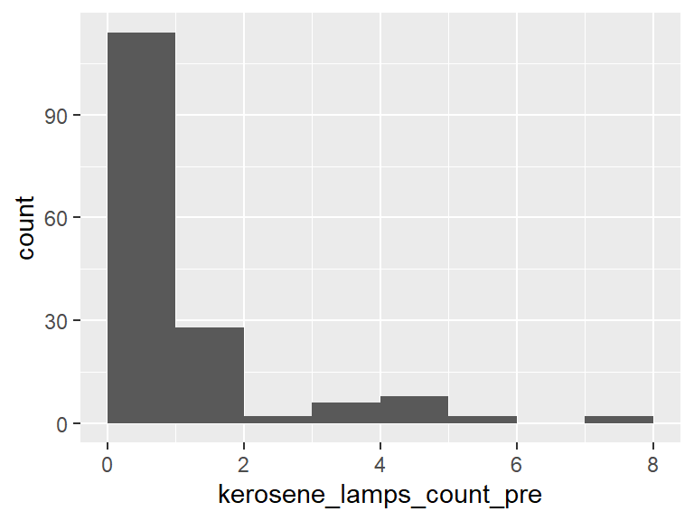

- The following suspected missing value codes enter as regular values: "8".
- Note that the following possible outlier values were detected: "6", "8".

## business_owners_count_pre

- Note that this variable is treated as a factor variable below, as it only takes a few unique values.

| Feature | Result |
| --- | --- |
| Variable type | integer |
| Number of missing obs. | 0 (0 %) |
| Number of unique values | 3 |
| Mode | “0” |
| Reference category | 0 |

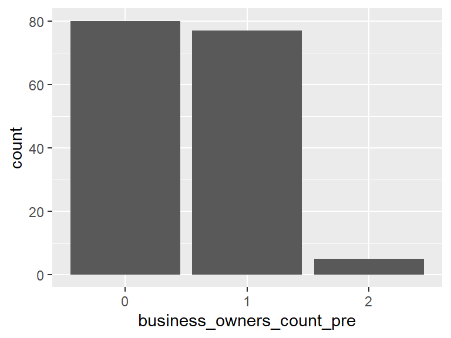

- Note that the following levels have at most five observations: "2".

## business_owners_female_pre

- Note that this variable is treated as a factor variable below, as it only takes a few unique values.

| Feature | Result |
| --- | --- |
| Variable type | integer |
| Number of missing obs. | 0 (0 %) |
| Number of unique values | 2 |
| Mode | “0” |
| Reference category | 0 |

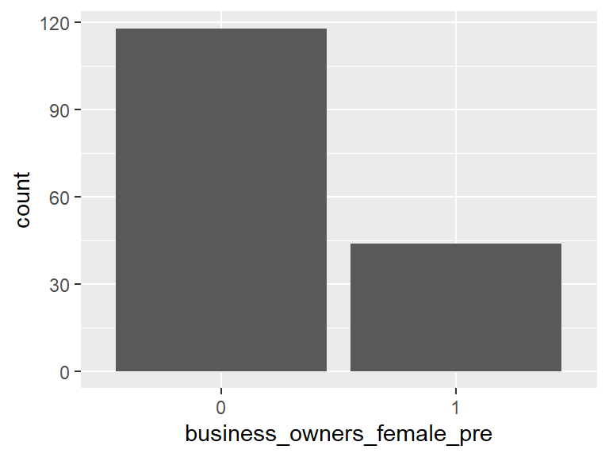

## community_lights_pre

- Note that this variable is treated as a factor variable below, as it only takes a few unique values.

| Feature | Result |
| --- | --- |
| Variable type | numeric |
| Number of missing obs. | 0 (0 %) |
| Number of unique values | 2 |
| Mode | “1” |
| Reference category | 0 |

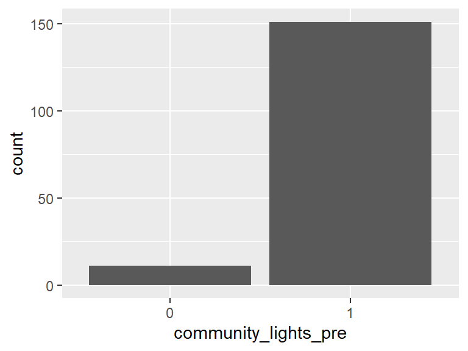

## home_exterior_lights_pre

- Note that this variable is treated as a factor variable below, as it only takes a few unique values.

| Feature | Result |
| --- | --- |
| Variable type | numeric |
| Number of missing obs. | 2 (1.23 %) |
| Number of unique values | 2 |
| Mode | “1” |
| Reference category | 0 |

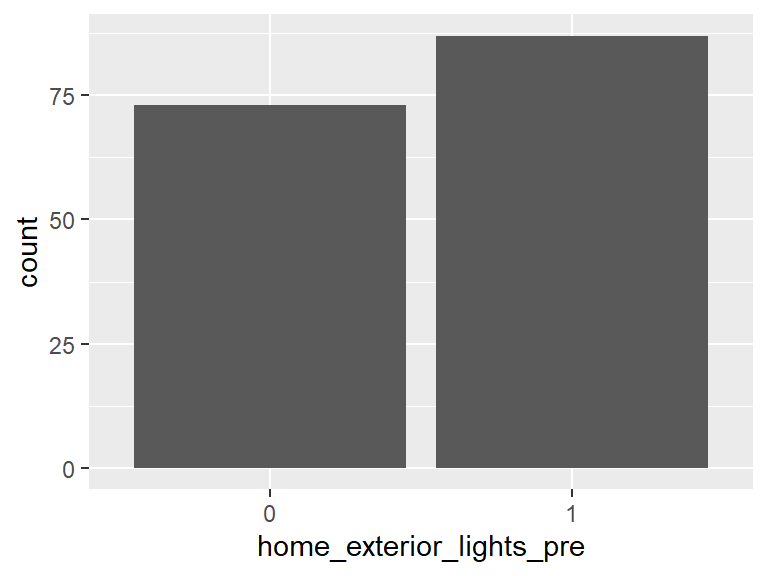

## clinic_refrigeration_access_pre

- Note that this variable is treated as a factor variable below, as it only takes a few unique values.

| Feature | Result |
| --- | --- |
| Variable type | numeric |
| Number of missing obs. | 7 (4.32 %) |
| Number of unique values | 2 |
| Mode | “1” |
| Reference category | 0 |

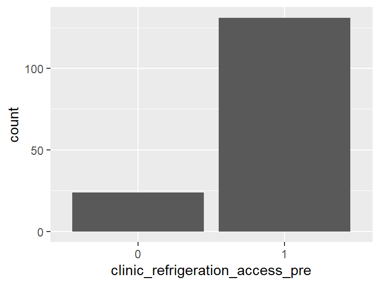

## cooking_fuel_collection_time_pre

- Note that this variable is treated as a factor variable below, as it only takes a few unique values.

| Feature | Result |
| --- | --- |
| Variable type | numeric |
| Number of missing obs. | 0 (0 %) |
| Number of unique values | 4 |
| Mode | “2” |
| Reference category | 1 |

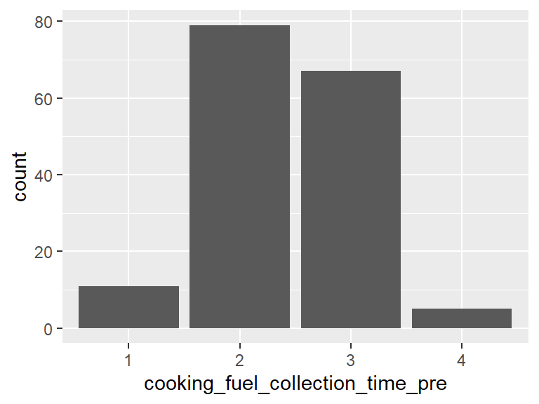

- Note that the following levels have at most five observations: "4".

## cooking_energy_cost_pre

- Note that this variable is treated as a factor variable below, as it only takes a few unique values.

| Feature | Result |
| --- | --- |
| Variable type | numeric |
| Number of missing obs. | 9 (5.56 %) |
| Number of unique values | 4 |
| Mode | “2” |
| Reference category | 2 |

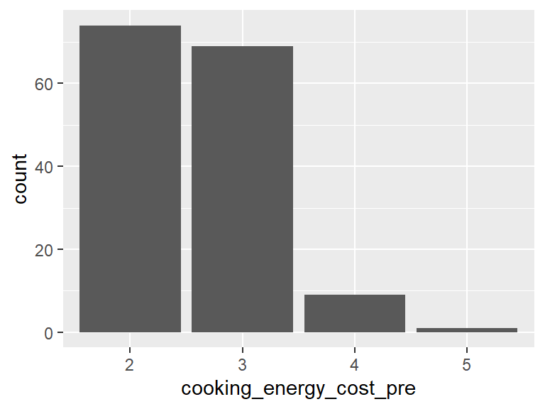

- Note that the following levels have at most five observations: "5".

## feel_safe_dark_pre

- Note that this variable is treated as a factor variable below, as it only takes a few unique values.

| Feature | Result |
| --- | --- |
| Variable type | numeric |
| Number of missing obs. | 0 (0 %) |
| Number of unique values | 5 |
| Mode | “1” |
| Reference category | 1 |

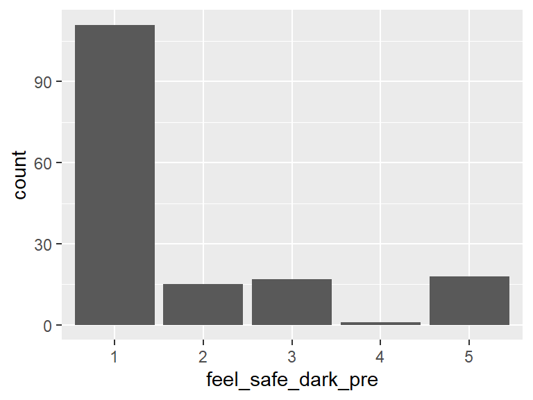

- Note that the following levels have at most five observations: "4".

## feel_safe_if_exterior_lights_pre

- Note that this variable is treated as a factor variable below, as it only takes a few unique values.

| Feature | Result |
| --- | --- |
| Variable type | numeric |
| Number of missing obs. | 0 (0 %) |
| Number of unique values | 5 |
| Mode | “5” |
| Reference category | 1 |

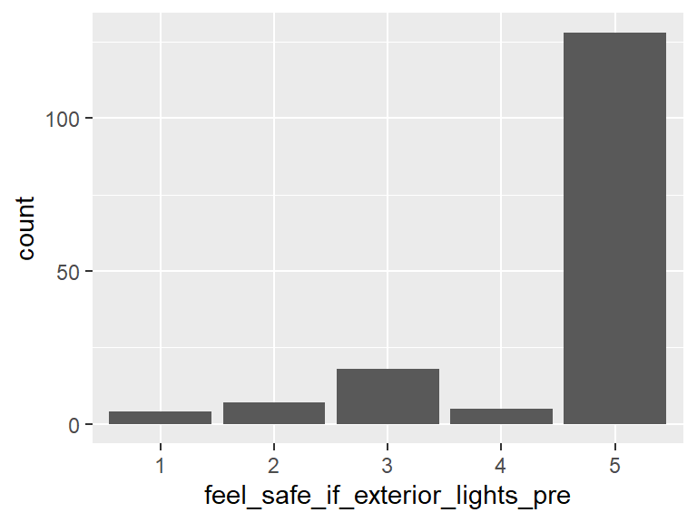

- Note that the following levels have at most five observations: "1", "4".

## water_source_pre

- Note that this variable is treated as a factor variable below, as it only takes a few unique values.

| Feature | Result |
| --- | --- |
| Variable type | numeric |
| Number of missing obs. | 1 (0.62 %) |
| Number of unique values | 4 |
| Mode | “3” |
| Reference category | 1 |

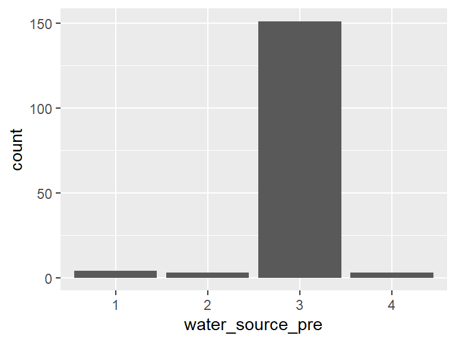

- Note that the following levels have at most five observations: "1", "2", "4".

## water_collection_travel_distance_pre

- Note that this variable is treated as a factor variable below, as it only takes a few unique values.

| Feature | Result |
| --- | --- |
| Variable type | numeric |
| Number of missing obs. | 17 (10.49 %) |
| Number of unique values | 4 |
| Mode | “3” |
| Reference category | 2 |

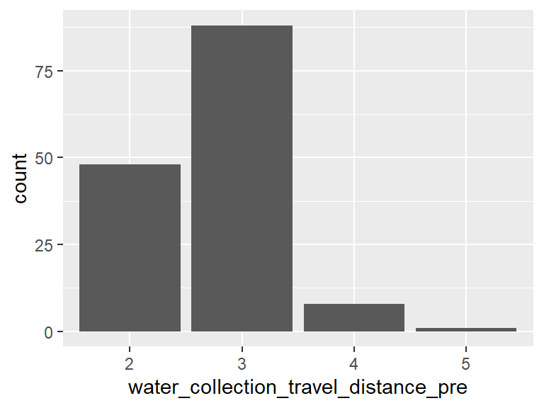

- Note that the following levels have at most five observations: "5".

## water_collection_time_pre

- Note that this variable is treated as a factor variable below, as it only takes a few unique values.

| Feature | Result |
| --- | --- |
| Variable type | numeric |
| Number of missing obs. | 3 (1.85 %) |
| Number of unique values | 5 |
| Mode | “2” |
| Reference category | 1 |

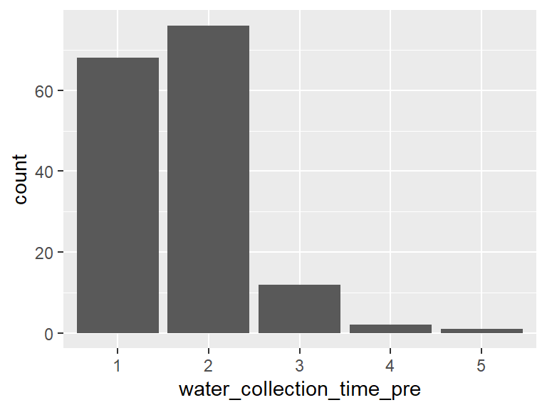

- Note that the following levels have at most five observations: "4", "5".

## water_cost_pre

- Note that this variable is treated as a factor variable below, as it only takes a few unique values.

| Feature | Result |
| --- | --- |
| Variable type | numeric |
| Number of missing obs. | 3 (1.85 %) |
| Number of unique values | 3 |
| Mode | “2” |
| Reference category | 1 |

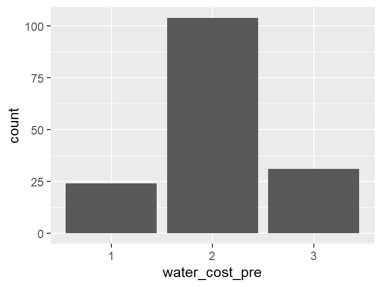

## clinic_travel_distance_pre

- Note that this variable is treated as a factor variable below, as it only takes a few unique values.

| Feature | Result |
| --- | --- |
| Variable type | numeric |
| Number of missing obs. | 96 (59.26 %) |
| Number of unique values | 3 |
| Mode | “2” |
| Reference category | 2 |

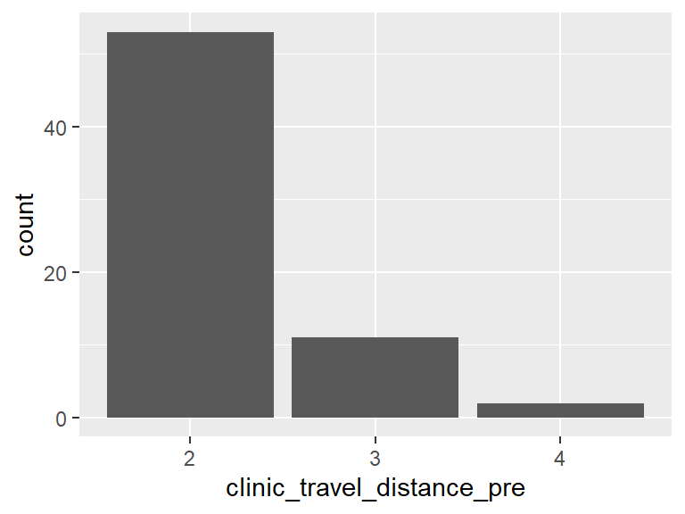

- Note that the following levels have at most five observations: "4".

## phone_charge_cost_pre

- Note that this variable is treated as a factor variable below, as it only takes a few unique values.

| Feature | Result |
| --- | --- |
| Variable type | numeric |
| Number of missing obs. | 25 (15.43 %) |
| Number of unique values | 4 |
| Mode | “3” |
| Reference category | 2 |

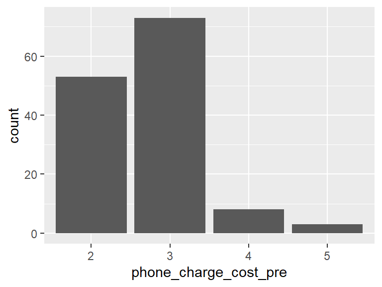

- Note that the following levels have at most five observations: "5".

## avg_household_income_post

| Feature | Result |
| --- | --- |
| Variable type | numeric |
| Number of missing obs. | 0 (0 %) |
| Number of unique values | 45 |
| Median | 4750 |
| 1st and 3rd quartiles | 2000; 7725 |
| Min. and max. | 0; 5e+05 |

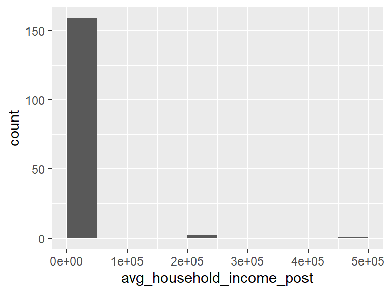

- Note that the following possible outlier values were detected: "24000", "25000", "30000", "32000", "35000", "36000", "250000", "5e+05".

## appliances_count_post

| Feature | Result |
| --- | --- |
| Variable type | numeric |
| Number of missing obs. | 0 (0 %) |
| Number of unique values | 6 |
| Median | 2 |
| 1st and 3rd quartiles | 1; 2 |
| Min. and max. | 0; 6 |

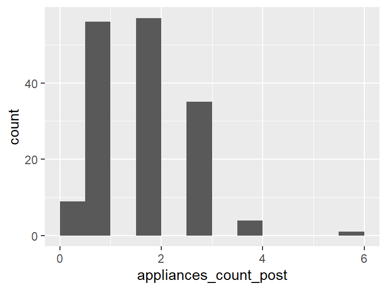

- Note that the following possible outlier values were detected: "4", "6".

## cellphones_count_post

| Feature | Result |
| --- | --- |
| Variable type | numeric |
| Number of missing obs. | 12 (7.41 %) |
| Number of unique values | 6 |
| Median | 2 |
| 1st and 3rd quartiles | 2; 2 |
| Min. and max. | 0; 5 |

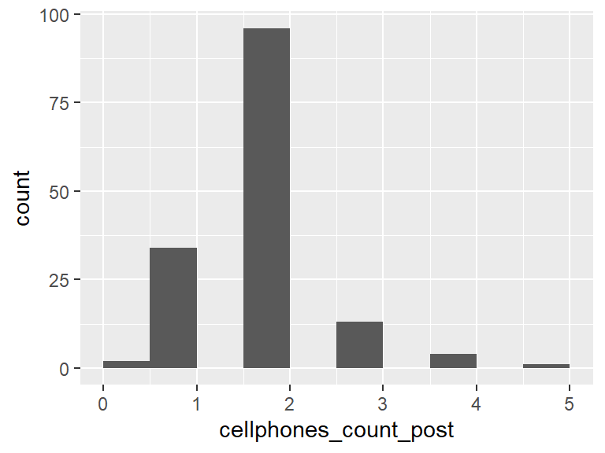

- Note that the following possible outlier values were detected: "0", "1", "3", "4", "5".

## light_hours_current_post

| Feature | Result |
| --- | --- |
| Variable type | numeric |
| Number of missing obs. | 4 (2.47 %) |
| Number of unique values | 11 |
| Median | 4 |
| 1st and 3rd quartiles | 3; 4 |
| Min. and max. | 0; 24 |

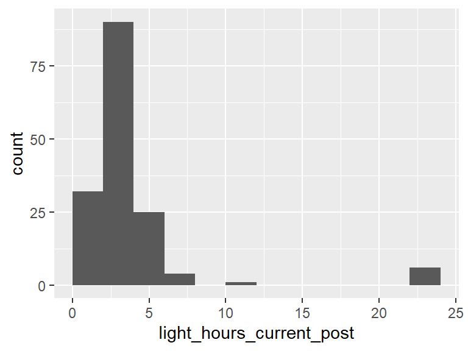

- Note that the following possible outlier values were detected: "5", "6", "7", "8", "12", "24".

## kerosene_lamps_count_post

| Feature | Result |
| --- | --- |
| Variable type | numeric |
| Number of missing obs. | 0 (0 %) |
| Number of unique values | 6 |
| Median | 1 |
| 1st and 3rd quartiles | 1; 2 |
| Min. and max. | 0; 7 |

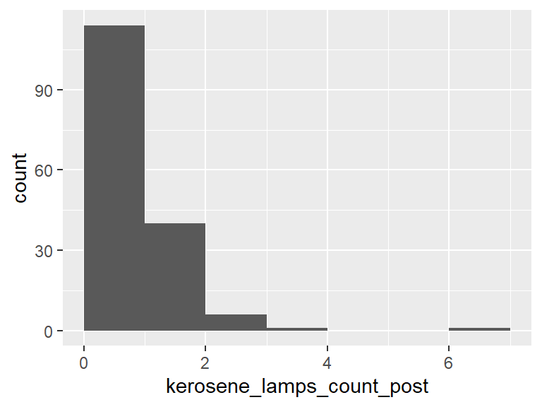

- Note that the following possible outlier values were detected: "0", "7".

## business_owners_count_post

- Note that this variable is treated as a factor variable below, as it only takes a few unique values.

| Feature | Result |
| --- | --- |
| Variable type | integer |
| Number of missing obs. | 0 (0 %) |
| Number of unique values | 2 |
| Mode | “0” |
| Reference category | 0 |

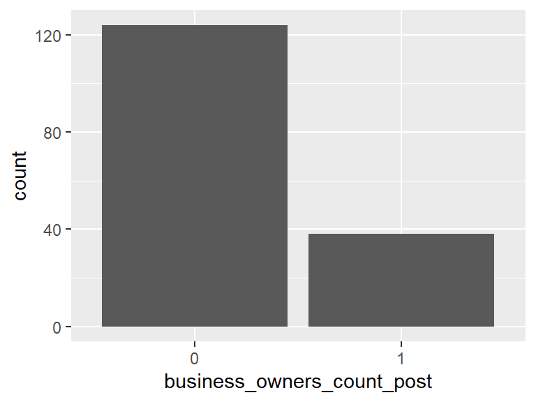

## business_owners_female_post

- Note that this variable is treated as a factor variable below, as it only takes a few unique values.

| Feature | Result |
| --- | --- |
| Variable type | integer |
| Number of missing obs. | 0 (0 %) |
| Number of unique values | 2 |
| Mode | “0” |
| Reference category | 0 |

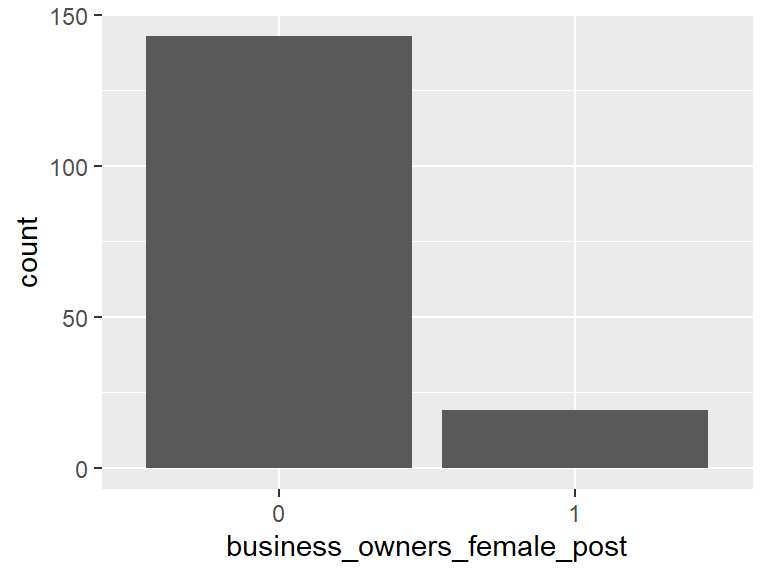

## community_lights_post

- Note that this variable is treated as a factor variable below, as it only takes a few unique values.

| Feature | Result |
| --- | --- |
| Variable type | numeric |
| Number of missing obs. | 0 (0 %) |
| Number of unique values | 2 |
| Mode | “0” |
| Reference category | 0 |

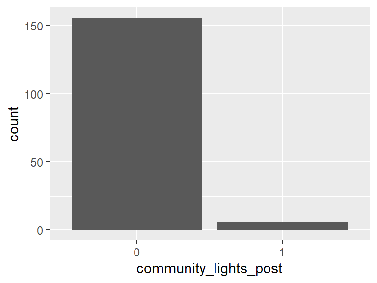

## home_exterior_lights_post

- Note that this variable is treated as a factor variable below, as it only takes a few unique values.

| Feature | Result |
| --- | --- |
| Variable type | numeric |
| Number of missing obs. | 2 (1.23 %) |
| Number of unique values | 2 |
| Mode | “0” |
| Reference category | 0 |

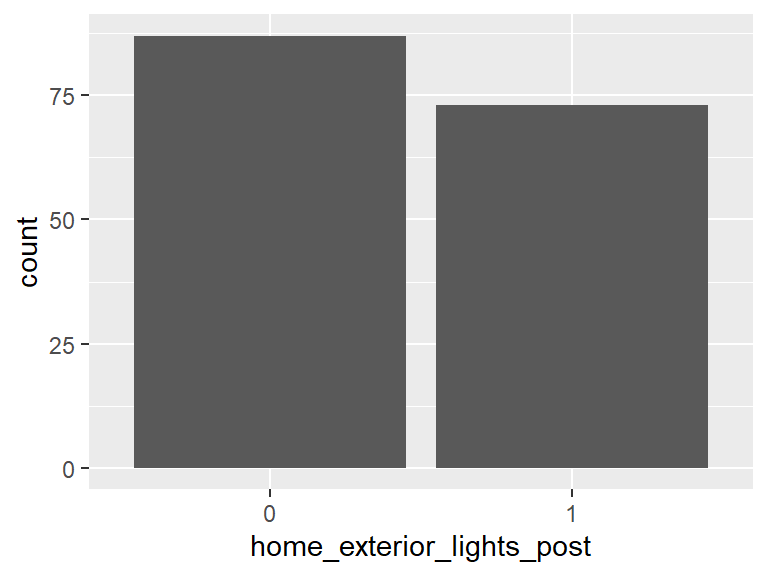

## clinic_refrigeration_access_post

- Note that this variable is treated as a factor variable below, as it only takes a few unique values.

| Feature | Result |
| --- | --- |
| Variable type | numeric |
| Number of missing obs. | 12 (7.41 %) |
| Number of unique values | 2 |
| Mode | “1” |
| Reference category | 0 |

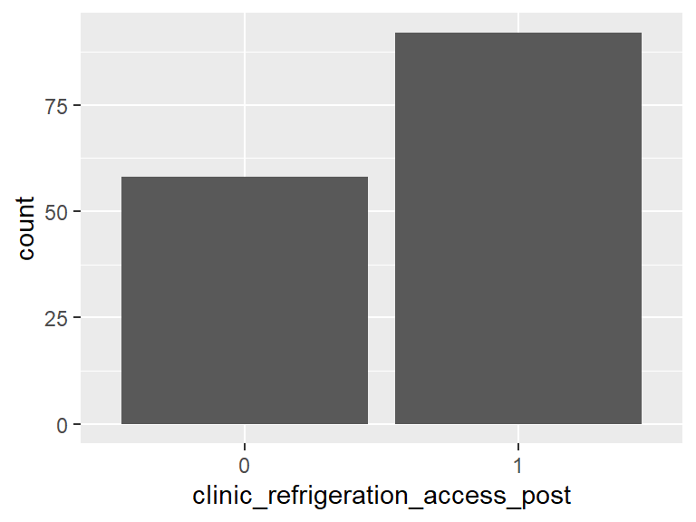

## cooking_fuel_collection_time_post

- Note that this variable is treated as a factor variable below, as it only takes a few unique values.

| Feature | Result |
| --- | --- |
| Variable type | numeric |
| Number of missing obs. | 0 (0 %) |
| Number of unique values | 4 |
| Mode | “2” |
| Reference category | 1 |

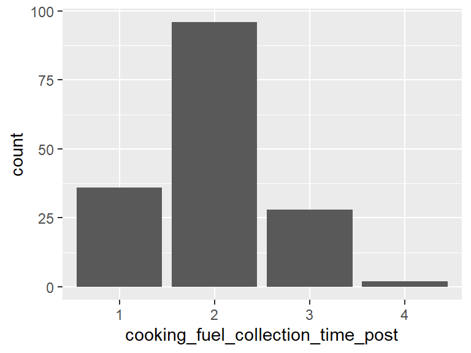

- Note that the following levels have at most five observations: "4".

## cooking_energy_cost_post

- Note that this variable is treated as a factor variable below, as it only takes a few unique values.

| Feature | Result |
| --- | --- |
| Variable type | numeric |
| Number of missing obs. | 0 (0 %) |
| Number of unique values | 3 |
| Mode | “1” |
| Reference category | 1 |

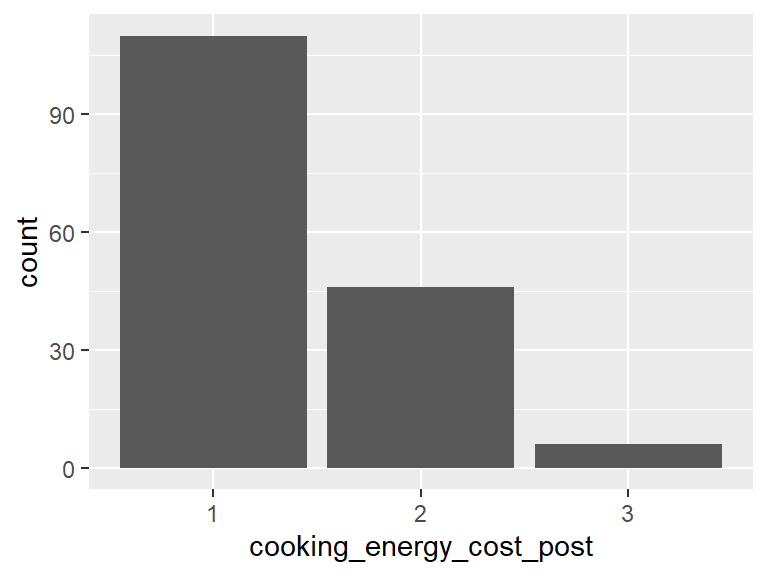

## feel_safe_dark_post

- Note that this variable is treated as a factor variable below, as it only takes a few unique values.

| Feature | Result |
| --- | --- |
| Variable type | numeric |
| Number of missing obs. | 0 (0 %) |
| Number of unique values | 5 |
| Mode | “1” |
| Reference category | 1 |

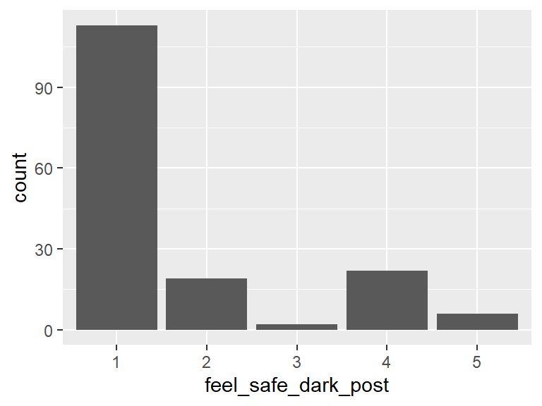

- Note that the following levels have at most five observations: "3".

## feel_safe_if_exterior_lights_post

- Note that this variable is treated as a factor variable below, as it only takes a few unique values.

| Feature | Result |
| --- | --- |
| Variable type | numeric |
| Number of missing obs. | 0 (0 %) |
| Number of unique values | 5 |
| Mode | “5” |
| Reference category | 1 |

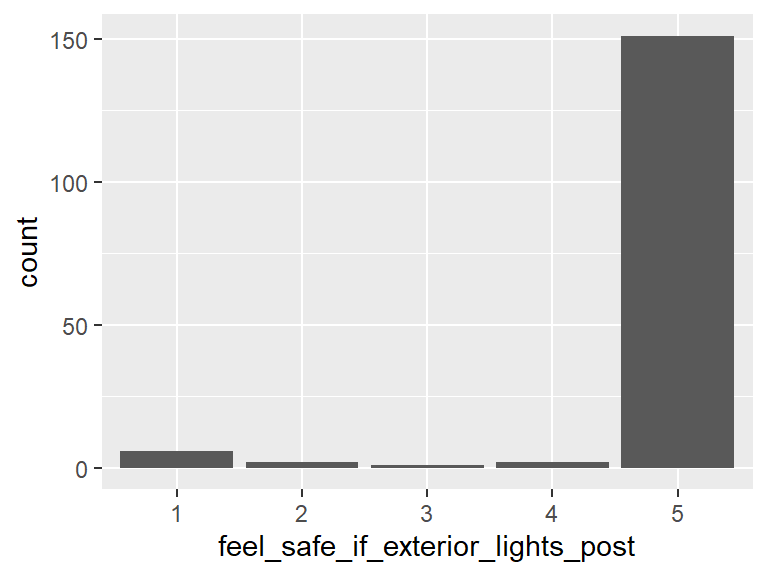

- Note that the following levels have at most five observations: "2", "3", "4".

## water_source_post

- Note that this variable is treated as a factor variable below, as it only takes a few unique values.

| Feature | Result |
| --- | --- |
| Variable type | numeric |
| Number of missing obs. | 4 (2.47 %) |
| Number of unique values | 3 |
| Mode | “3” |
| Reference category | 2 |

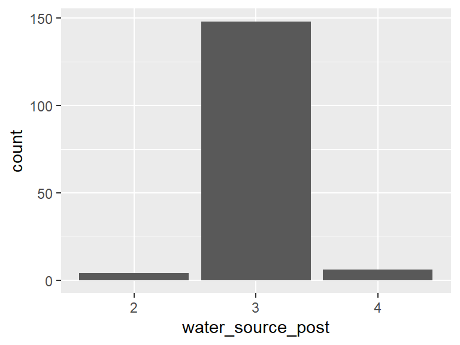

- Note that the following levels have at most five observations: "2".

## water_collection_travel_distance_post

- Note that this variable is treated as a factor variable below, as it only takes a few unique values.

| Feature | Result |
| --- | --- |
| Variable type | numeric |
| Number of missing obs. | 0 (0 %) |
| Number of unique values | 4 |
| Mode | “2” |
| Reference category | 1 |

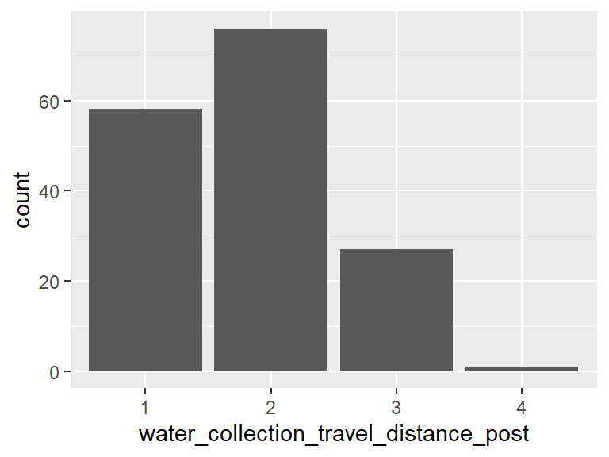

- Note that the following levels have at most five observations: "4".

## water_collection_time_post

- Note that this variable is treated as a factor variable below, as it only takes a few unique values.

| Feature | Result |
| --- | --- |
| Variable type | numeric |
| Number of missing obs. | 0 (0 %) |
| Number of unique values | 5 |
| Mode | “2” |
| Reference category | 1 |

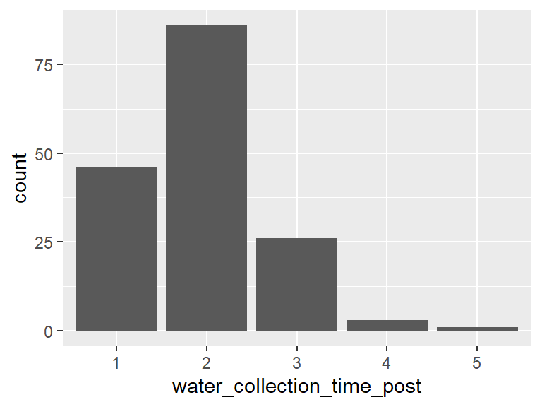

- Note that the following levels have at most five observations: "4", "5".

## water_cost_post

- Note that this variable is treated as a factor variable below, as it only takes a few unique values.

| Feature | Result |
| --- | --- |
| Variable type | numeric |
| Number of missing obs. | 0 (0 %) |
| Number of unique values | 3 |
| Mode | “2” |
| Reference category | 1 |

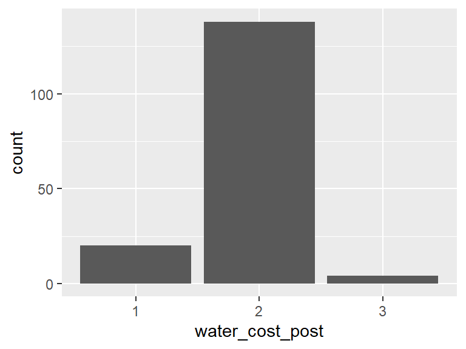

- Note that the following levels have at most five observations: "3".

## clinic_travel_distance_post

- Note that this variable is treated as a factor variable below, as it only takes a few unique values.

| Feature | Result |
| --- | --- |
| Variable type | numeric |
| Number of missing obs. | 99 (61.11 %) |
| Number of unique values | 4 |
| Mode | “2” |
| Reference category | 2 |

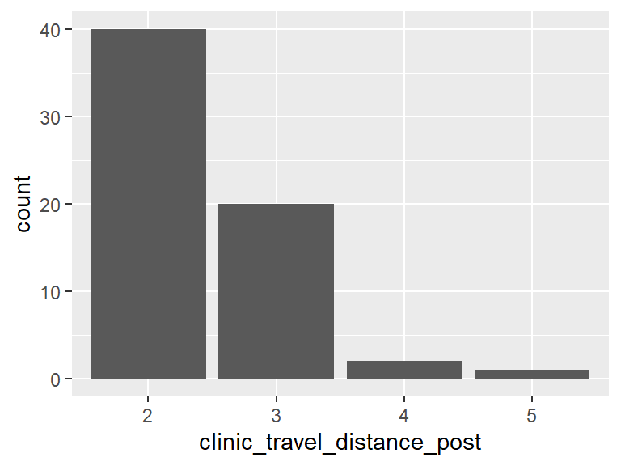

- Note that the following levels have at most five observations: "4", "5".

## phone_charge_cost_post

- The variable only takes one value: "NA".

Report generation information:

- Created by: Akoua Orsot~ (username: `User`).
- Report creation time: Thu Oct 05 2023 21:01:21
- Report was run from directory: `\\wsl.localhost/Ubuntu/home/aorsot/Renewvia/survey_impact_analysis`
- dataMaid v1.4.1 [Pkg: 2021-10-08 from CRAN (R 4.3.1)]
- R version 4.3.1 (2023-06-16 ucrt).
- Platform: x86_64-w64-mingw32/x64 (64-bit)(Etc/UTC).
- Function call: `makeDataReport(data = df, output = "html", replace = TRUE)`